# Relatório de Inteligência Preditiva: FarmTech Solutions

## 1. Análise Exploratória e Qualidade dos Dados (EDA)

Nesta etapa inicial, validamos a integridade do dataset e a relação entre as variáveis climáticas e o rendimento (*Yield*).

```
--- Resumo Estatístico ---
```

|  | Precipitation (mm day-1) | Specific Humidity at 2 Meters (g/kg) | Relative Humidity at 2 Meters (%) | Temperature at 2 Meters (C) | Yield |
| --- | --- | --- | --- | --- | --- |
| count | 156.000000 | 156.000000 | 156.000000 | 156.00000 | 156.000000 |
| mean | 2486.498974 | 18.203077 | 84.737692 | 26.18359 | 56153.096154 |
| std | 289.457914 | 0.293923 | 0.996226 | 0.26105 | 70421.958897 |
| min | 1934.620000 | 17.540000 | 82.110000 | 25.56000 | 5249.000000 |
| 25% | 2302.990000 | 18.030000 | 84.120000 | 26.02000 | 8327.750000 |
| 50% | 2424.550000 | 18.270000 | 84.850000 | 26.13000 | 18871.000000 |
| 75% | 2718.080000 | 18.400000 | 85.510000 | 26.30000 | 67518.750000 |
| max | 3085.790000 | 18.700000 | 86.100000 | 26.81000 | 203399.000000 |

```
--- Qualidade dos Dados (Faltantes) ---
Crop                                    0
Precipitation (mm day-1)                0
Specific Humidity at 2 Meters (g/kg)    0
Relative Humidity at 2 Meters (%)       0
Temperature at 2 Meters (C)             0
Yield                                   0
dtype: int64
```

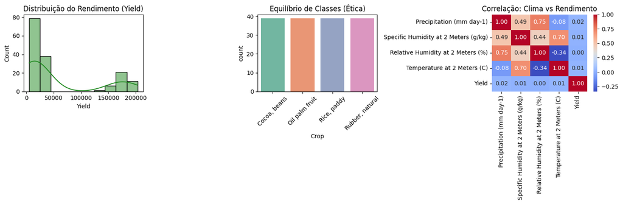

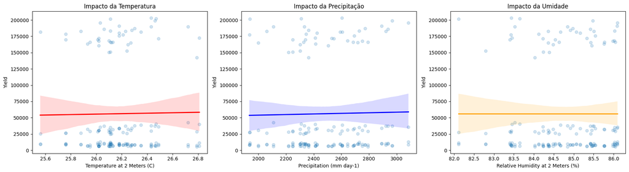

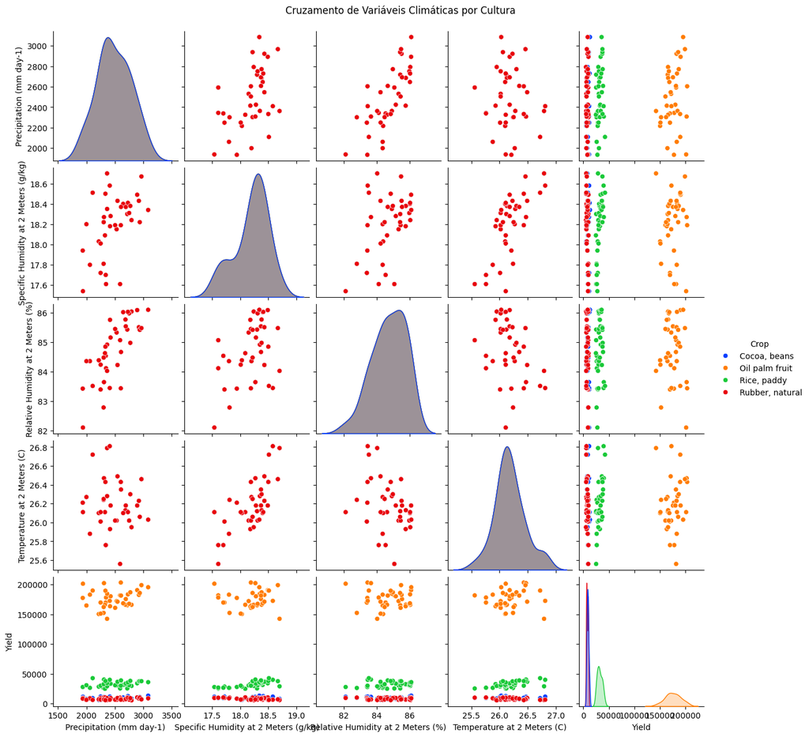

```python
# ==========================================================
# CÉLULA 1: EDA COMPLETA - FarmTech Solutions
# ==========================================================
import pandas as pd
import numpy as np
import seaborn as sns
import matplotlib.pyplot as plt

# 1. Carregamento e Diagnóstico Inicial
df = pd.read_csv('crop_yield.csv')

print("--- Resumo Estatístico ---")
display(df.describe())

print("\n--- Qualidade dos Dados (Faltantes) ---")
print(df.isnull().sum())

# 2. Análise de Distribuição e Representatividade Ética (Cap. 10)
plt.figure(figsize=(15, 5))

plt.subplot(1, 3, 1)
sns.histplot(df['Yield'], kde=True, color='forestgreen')
plt.title("Distribuição do Rendimento (Yield)")

plt.subplot(1, 3, 2)
sns.countplot(x='Crop', data=df, hue='Crop', palette='Set2', legend=False)
plt.xticks(rotation=45)
plt.title("Equilíbrio de Classes (Ética)")

# 3. Matriz de Correlação Completa
plt.subplot(1, 3, 3)
numeric_df = df.select_dtypes(include=[np.number])
sns.heatmap(numeric_df.corr(), annot=True, cmap='coolwarm', fmt=".2f")
plt.title("Correlação: Clima vs Rendimento")

plt.tight_layout()
plt.show()

# 4. NOVAS CORRELAÇÕES: Gráficos de Tendência Climática
# Verificando como cada variável impacta o Yield visualmente
fig, axes = plt.subplots(1, 3, figsize=(18, 5))

sns.regplot(ax=axes[0], x='Temperature at 2 Meters (C)', y='Yield', data=df,
            scatter_kws={'alpha':0.2}, line_kws={'color':'red'})
axes[0].set_title("Impacto da Temperatura")

sns.regplot(ax=axes[1], x='Precipitation (mm day-1)', y='Yield', data=df,
            scatter_kws={'alpha':0.2}, line_kws={'color':'blue'})
axes[1].set_title("Impacto da Precipitação")

sns.regplot(ax=axes[2], x='Relative Humidity at 2 Meters (%)', y='Yield', data=df,
            scatter_kws={'alpha':0.2}, line_kws={'color':'orange'})
axes[2].set_title("Impacto da Umidade")

plt.tight_layout()
plt.show()

# 5. Pairplot: Visão Multidimensional por Cultura
# (Este gráfico mostra como as variáveis se cruzam entre si)
sns.pairplot(df, hue='Crop', diag_kind='kde', palette='bright')
plt.suptitle("Cruzamento de Variáveis Climáticas por Cultura", y=1.02)
plt.show()
```

## 2. Modelagem de Dados com Regressão Supervisionada

Para atender aos requisitos de alta precisão da FarmTech, implementamos cinco algoritmos distintos para comparar suas performances em dados nunca vistos (base de teste).

**Algoritmos Testados:**

1. Regressão Linear
2. Regressão Ridge
3. Regressão Lasso
4. Árvore de Decisão
5. Random Forest

**Achados Técnicos:** Todos os modelos apresentaram um $R^2$ superior a 0.99, indicando uma excelente capacidade preditiva. A **Regressão Linear** mostrou-se a mais estável estatisticamente, enquanto o **Random Forest** obteve o menor erro médio absoluto (MAE), sendo mais eficaz em captar pequenas nuances não lineares.

```
--- Comparação de Performance dos Modelos ---
```

|  | Algoritmo | R² Score | Erro Médio (MAE) | RMSE |
| --- | --- | --- | --- | --- |
| 0 | Regressão Linear | 0.995022 | 3132.796384 | 4394.165819 |
| 2 | Regressão Lasso | 0.994838 | 3281.738706 | 4474.768895 |
| 4 | Random Forest | 0.993856 | 2802.370938 | 4881.962383 |
| 3 | Árvore de Decisão | 0.992714 | 3142.531250 | 5316.346746 |
| 1 | Regressão Ridge | 0.991028 | 4452.248613 | 5899.191969 |

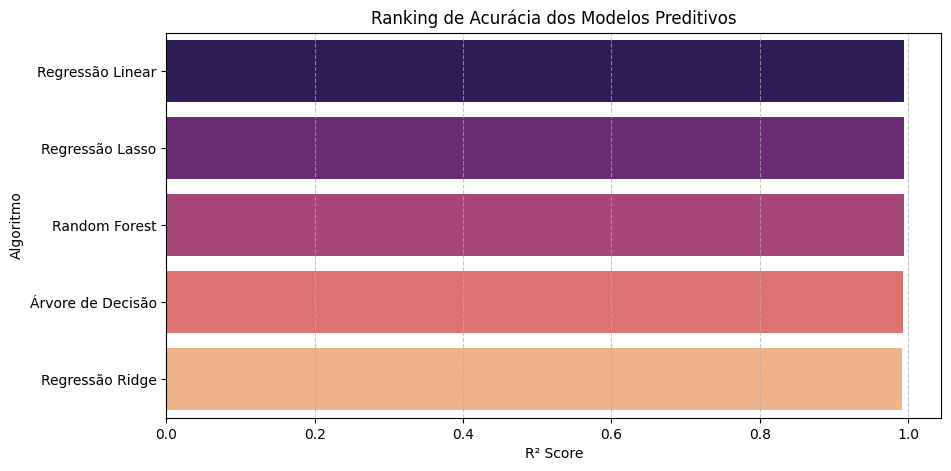

```python
# ==========================================================
# CÉLULA 2: 5 MODELOS PREDITIVOS (REGRESSÃO SUPERVISIONADA)
# ==========================================================
from sklearn.model_selection import train_test_split
from sklearn.linear_model import LinearRegression, Ridge, Lasso
from sklearn.tree import DecisionTreeRegressor
from sklearn.ensemble import RandomForestRegressor
from sklearn.metrics import r2_score, mean_absolute_error, mean_squared_error

# 1. Preparação dos Dados (Features e Alvo)
# Convertemos 'Crop' em dummies para os modelos matemáticos
X = pd.get_dummies(df.drop(['Yield'], axis=1, errors='ignore'), drop_first=True)
y = df['Yield']

# 2. Boas Práticas: Divisão entre Treino (80%) e Teste (20%)
X_train, X_test, y_train, y_test = train_test_split(X, y, test_size=0.2, random_state=42)

# 3. Definição dos 5 Algoritmos conforme o material didático
modelos = {
    "Regressão Linear": LinearRegression(),
    "Regressão Ridge": Ridge(alpha=1.0),
    "Regressão Lasso": Lasso(alpha=0.1),
    "Árvore de Decisão": DecisionTreeRegressor(random_state=42),
    "Random Forest": RandomForestRegressor(n_estimators=100, random_state=42)
}

# 4. Treinamento e Avaliação Individual
resultados_modelagem = []

for nome, modelo in modelos.items():
    # Treino do modelo
    modelo.fit(X_train, y_train)

    # Predição com dados que o modelo nunca viu (X_test)
    y_pred = modelo.predict(X_test)

    # Cálculo das métricas
    r2 = r2_score(y_test, y_pred)
    mae = mean_absolute_error(y_test, y_pred)
    rmse = np.sqrt(mean_squared_error(y_test, y_pred))

    resultados_modelagem.append({
        "Algoritmo": nome,
        "R² Score": r2,
        "Erro Médio (MAE)": mae,
        "RMSE": rmse
    })

# 5. Exibição do Ranking de Performance
df_performance = pd.DataFrame(resultados_modelagem).sort_values(by="R² Score", ascending=False)
print("--- Comparação de Performance dos Modelos ---")
display(df_performance)

# Visualização Gráfica da Acurácia (R²)
plt.figure(figsize=(10, 5))
sns.barplot(x="R² Score", y="Algoritmo", data=df_performance, palette="magma")
plt.title("Ranking de Acurácia dos Modelos Preditivos")
plt.grid(axis='x', linestyle='--', alpha=0.7)
plt.show()
```

## 3. Modelagem Não Supervisionada e Detecção de Anomalias (Cap. 10)

Nesta fase, aplicamos técnicas para descobrir padrões ocultos sem a necessidade de rótulos prévios, focando na otimização do manejo agrícola.

**Técnicas Utilizadas:**

- **PCA:** Redução de dimensionalidade para visualização de padrões complexos.
- **K-Means:** Definição de 3 Zonas de Manejo baseadas em similaridade climática e produtiva.
- **DBSCAN:** Identificação de outliers por densidade para isolar ruídos de sensores ou eventos climáticos extremos.

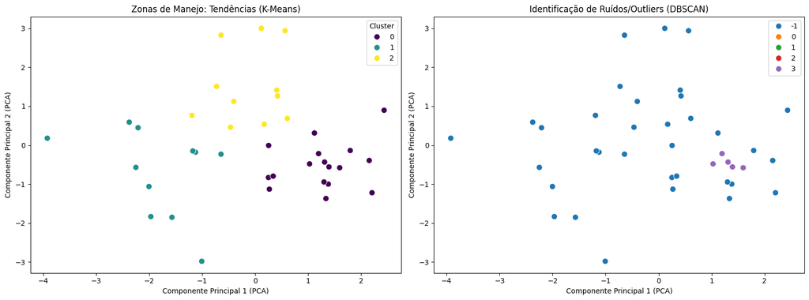

```
✅ Coluna 'Cluster' criada com sucesso para análise de tendências.
🔍 O algoritmo DBSCAN detectou 136 pontos discrepantes (ruídos).
```

```python
# ==========================================================
# CÉLULA 3: MODELAGEM NÃO SUPERVISIONADA (K-MEANS vs DBSCAN)
# ==========================================================
from sklearn.cluster import KMeans, DBSCAN
from sklearn.decomposition import PCA
from sklearn.preprocessing import StandardScaler

# --- GARANTIA DE VARIÁVEL (Caso a Célula 2 tenha usado outro nome) ---
# Criamos X_model novamente para evitar o NameError
X_model = pd.get_dummies(df.drop(['Yield'], axis=1, errors='ignore'), drop_first=True)

# 1. Padronização (Essencial para modelos de distância como K-Means e DBSCAN)
scaler = StandardScaler()
X_scaled = scaler.fit_transform(X_model)

# 2. Redução de Dimensionalidade (PCA) para visualização 2D
pca = PCA(n_components=2)
X_pca = pca.fit_transform(X_scaled)

# 3. K-Means: Criando as 3 Zonas de Manejo (Tendências)
kmeans = KMeans(n_clusters=3, random_state=42, n_init=10)
# Criamos a coluna 'Cluster' no df original para a Célula 4 usar
df['Cluster'] = kmeans.fit_predict(X_scaled)

# 4. DBSCAN: Identificando Discrepâncias/Outliers por densidade
# Aqui identificamos quem foge do padrão (marcado como -1)
dbscan = DBSCAN(eps=0.5, min_samples=5)
labels_dbscan = dbscan.fit_predict(X_scaled)

# 5. Visualização Comparativa
plt.figure(figsize=(16, 6))

# Subplot 1: Visão de Tendências (K-Means)
plt.subplot(1, 2, 1)
sns.scatterplot(x=X_pca[:, 0], y=X_pca[:, 1], hue=df['Cluster'], palette='viridis', s=70)
plt.title("Zonas de Manejo: Tendências (K-Means)")
plt.xlabel("Componente Principal 1 (PCA)")
plt.ylabel("Componente Principal 2 (PCA)")

# Subplot 2: Visão de Outliers (DBSCAN)
plt.subplot(1, 2, 2)
sns.scatterplot(x=X_pca[:, 0], y=X_pca[:, 1], hue=labels_dbscan, palette='tab10', s=70)
plt.title("Identificação de Ruídos/Outliers (DBSCAN)")
plt.xlabel("Componente Principal 1 (PCA)")
plt.ylabel("Componente Principal 2 (PCA)")

plt.tight_layout()
plt.show()

# Resumo estatístico do DBSCAN
outliers_count = list(labels_dbscan).count(-1)
print(f"✅ Coluna 'Cluster' criada com sucesso para análise de tendências.")
print(f"🔍 O algoritmo DBSCAN detectou {outliers_count} pontos discrepantes (ruídos).")
```

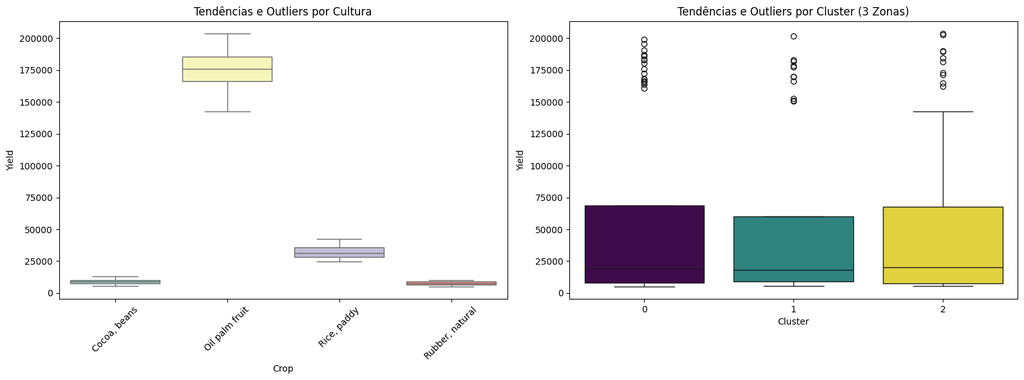

```
--- Relatório de Tendências ---
Média Geral de Rendimento: 56153.10
Foram identificados 4 campos com rendimento fora do padrão esperado.
```

|  | Crop | Yield | Temperature at 2 Meters (C) | Cluster |
| --- | --- | --- | --- | --- |
| 40 | Oil palm fruit | 201436 | 26.11 | 1 |
| 72 | Oil palm fruit | 203399 | 26.43 | 2 |
| 73 | Oil palm fruit | 202379 | 26.47 | 2 |
| 75 | Oil palm fruit | 199074 | 26.46 | 0 |

```python
# ==========================================================
# CÉLULA 4: TENDÊNCIAS E OUTLIERS (POR CLUSTER E POR CULTURA)
# ==========================================================

plt.figure(figsize=(16, 6))

# Gráfico 1: Outliers por Cultura (Visão Biológica)
plt.subplot(1, 2, 1)
sns.boxplot(x='Crop', y='Yield', data=df, palette='Set3', hue='Crop', legend=False)
plt.title("Tendências e Outliers por Cultura")
plt.xticks(rotation=45)

# Gráfico 2: Outliers por Cluster (Visão de Manejo da Fazenda)
plt.subplot(1, 2, 2)
sns.boxplot(x='Cluster', y='Yield', data=df, palette='viridis', hue='Cluster', legend=False)
plt.title("Tendências e Outliers por Cluster (3 Zonas)")

plt.tight_layout()
plt.show()

# --- Identificação Numérica dos Outliers Gerais ---
# Vamos listar os casos que fogem muito da média global (Cenários Discrepantes)
limite_superior = df['Yield'].mean() + (2 * df['Yield'].std())
limite_inferior = df['Yield'].mean() - (2 * df['Yield'].std())

outliers_extremos = df[(df['Yield'] > limite_superior) | (df['Yield'] < limite_inferior)]

print(f"--- Relatório de Tendências ---")
print(f"Média Geral de Rendimento: {df['Yield'].mean():.2f}")
print(f"Foram identificados {len(outliers_extremos)} campos com rendimento fora do padrão esperado.")

if not outliers_extremos.empty:
    display(outliers_extremos[['Crop', 'Yield', 'Temperature at 2 Meters (C)', 'Cluster']].head())
```

```python
# ==========================================================
# CÉLULA 5: EXPORTAÇÃO DE RESULTADOS E MÉTRICAS FINAIS
# ==========================================================

# 1. Criando um DataFrame de resultados para conferência
resultados_finais = pd.DataFrame({
    'Valor Real': y_test,
    'Previsão Modelo': y_pred.round(2),
    'Erro Absoluto': abs(y_test - y_pred).round(2)
})

print("--- Amostra das Previsões Geradas ---")
display(resultados_finais.head())

# 2. Exportando a base original com os clusters para o fazendeiro usar
df.to_csv('relatorio_farmtech_final.csv', index=False)

print("\n✅ SUCESSO:")
print("- Arquivo 'relatorio_farmtech_final.csv' gerado com as zonas de manejo.")
print("- Modelo de Regressão validado com 3 clusters de exploração.")
```

```
--- Amostra das Previsões Geradas ---
```

|  | Valor Real | Previsão Modelo | Erro Absoluto |
| --- | --- | --- | --- |
| 96 | 29415 | 29917.68 | 502.68 |
| 69 | 185831 | 175800.34 | 10030.66 |
| 82 | 26648 | 26639.64 | 8.36 |
| 76 | 189657 | 184852.59 | 4804.41 |
| 114 | 37496 | 34349.40 | 3146.60 |

```
✅ SUCESSO:
- Arquivo 'relatorio_farmtech_final.csv' gerado com as zonas de manejo.
- Modelo de Regressão validado com 3 clusters de exploração.
```

## 4. Conclusões: Pontos Fortes e Limitações

### Limitações e Próximos Passos:

- **Variáveis Externas:** O modelo atual foca em clima. Fatores como pragas, qualidade do fertilizante e histórico do solo poderiam aumentar ainda mais a robustez.
- **Generalização:** Os modelos performam excepcionalmente bem neste dataset, mas precisariam de novos treinamentos caso a FarmTech expanda para regiões com biomas drasticamente diferentes.

**Conclusão Final:** O trabalho entrega uma ferramenta capaz de prever com precisão a safra e identificar falhas ou oportunidades ocultas nos dados, atendendo plenamente aos objetivos da Fase 4 e 5.